# DS Capstone Project Milestone Report

Kyle Tan

Friday, October 02, 2015

#### Objectives

This report documents the steps taken to load, clean, explore and prepare the SWIFTKEY dataset for eventual modeling of the “next word” prediction algorithm.

#### 01 Load R Dependencies

The required R libraries are preloaded.

```r
# load libraries
library(dplyr)
library(stringi)
library(tm)
library(RWeka)
library(ggplot2)
library(wordcloud)
```

#### 01 Download Data Files

The SWIFTKEY dataset is downloaded.

```r
# download data file
if (!file.exists("01_raw/Coursera-SwiftKey.zip")) {
    download.file("https://d396qusza40orc.cloudfront.net/dsscapstone/dataset/Coursera-SwiftKey.zip",
        destfile = "01_raw/Coursera-SwiftKey.zip")
}
# unzip data file
if (!file.exists("01_raw/final/en_US/en_US.blogs.txt")) {
    unzip("01_raw/Coursera-SwiftKey.zip", exdir = "01_raw")
}
```

#### 02 Import Raw Data

The 3 data files are loaded.

```r
# load blogs dataset
blogs_file <- file("01_raw/final/en_US/en_US.blogs.txt", "rb")
blogs <- readLines(blogs_file, encoding="UTF-8")
close(blogs_file)

# load news dataset
news_file <- file("01_raw/final/en_US/en_US.news.txt", "rb")
news <- readLines(news_file, encoding="UTF-8")
close(news_file)

# load twitter dataset
twitter_file <- file("01_raw/final/en_US/en_US.twitter.txt", "rb")
twitter <- readLines(twitter_file, encoding="UTF-8")
close(twitter_file)
```

#### 03 Intitial Data Exploration

```r
# word count
raw_wpl <- sapply(list(blogs,news,twitter), stri_count_words)

# general statistical summary
raw_summ <- data.frame(
                RawFile = c("blogs","news","twitter"),
                t(sapply(list(blogs,news,twitter), stri_stats_general)),
                Words = t(sapply(list(blogs,news,twitter), stri_stats_latex)[4]),
                WPL = rbind(summary(raw_wpl[[1]]),summary(raw_wpl[[2]]),summary(raw_wpl[[3]]))
        )
print(raw_summ)
```

```
##   RawFile   Lines LinesNEmpty     Chars CharsNWhite    Words WPL.Min.
## 1   blogs  899288      899288 206824382   170389539 37570839        0
## 2    news 1010242     1010242 203223154   169860866 37570839        1
## 3 twitter 2360148     2360148 162096031   134082634 37570839        1
##   WPL.1st.Qu. WPL.Median WPL.Mean WPL.3rd.Qu. WPL.Max.
## 1           9         28    41.75          60     6726
## 2          19         32    34.41          46     1796
## 3           7         12    12.75          18       47
```

#### 04 Sample Data

1% of lines from each file is sampled, and resulting word chunk contains 1,029,958 words.

```r
set.seed(88888)
sampleSize <- 0.01 # 1% sampling
blogs_Sample <- sample(blogs, length(blogs)*sampleSize, replace=FALSE)
news_Sample <- sample(news, length(news)*sampleSize, replace=FALSE)
twitter_Sample <- sample(twitter, length(twitter)*sampleSize, replace=FALSE)
words_Sample <- c(blogs_Sample, news_Sample, twitter_Sample)
sum(stri_count_words(words_Sample))
```

```
## [1] 1029958
```

#### 05 Cleaning Data

A Text Corpus (structured set of texts) is created from the character vector. The following pre-processing is being performed to clean the data:

1. remove ASCII and Latin characters
2. convert to lower case
3. remove stopwords (e.g. the, its, a)
4. remove vulgarities *
5. remove punctuations
6. remove numbers
7. eliminating extra whitespace

*List of profanities from (https://gist.github.com/tjrobinson/2366772) loaded for cleaning data.

```r
createCorpus <- function(char_Vector) {
        # reads from a vector source to create a 'volatile corpus'
        corpus <- VCorpus(VectorSource(char_Vector))
}
cleanCorpus <- function(corpus) {
        # remove ASCII and Latin characters (enables conversion to lower case)
        corpus <- tm_map(corpus, content_transformer( function(x) iconv(x, "latin1", "ASCII", sub="") ) )
        # convert to lower case
        corpus <- tm_map(corpus, content_transformer(tolower))
        # remove stopwords
        corpus <- tm_map(corpus, removeWords, stopwords("english"))
        # remove vulgarities
        corpus <- tm_map(corpus, removeWords, profanity)
        # remove punctuations
        corpus <- tm_map(corpus, removePunctuation)
        # remove numbers
        corpus <- tm_map(corpus, removeNumbers)
        # eliminating extra whitespace
        corpus <- tm_map(corpus, stripWhitespace)
}
# load profanity list
profanity_file <- file("01_raw/profanity_list.txt", "rb")
profanity <- readLines(profanity_file, encoding="UTF-8")
close(profanity_file)
# create Corpus
text_Corpus <- createCorpus(words_Sample)
# clean Corpus
text_Corpus <- cleanCorpus(text_Corpus)
```

#### 06 Tokenize Data

The Text Corpus is Tokenized to form a Text Document Matrix (TDM - matrix of Terms and their frequencies across each document/line). The frequency of each term is then counted from the TDM.

```r
# Tokenizer Functions
BigramTokenizer <- function(x) NGramTokenizer(x, Weka_control(min = 2, max = 2))
TrigramTokenizer <- function(x) NGramTokenizer(x, Weka_control(min = 3, max = 3))
QuadgramTokenizer <- function(x) NGramTokenizer(x, Weka_control(min = 4, max = 4))
# Count Document Matrix Freq Functions
countTermFreq <- function(TDM, sparse_level){
        # remove sparse rows
        TDM1 <- removeSparseTerms(TDM, sparse_level)
        # sum across row to get total freq for each Term
        freq_terms <- sort(rowSums(as.matrix(TDM1)), decreasing=TRUE)
        # return data frame of words + freq count
        freq_df <- data.frame(word=names(freq_terms), freq=freq_terms)
        return(freq_df)
}
# constructs term document matrix (describing freq of terms)
TDM_1gram <- TermDocumentMatrix(text_Corpus)
TDM_2gram <- TermDocumentMatrix(text_Corpus, control = list(tokenize = BigramTokenizer))
TDM_3gram <- TermDocumentMatrix(text_Corpus, control = list(tokenize = TrigramTokenizer))
TDM_4gram <- TermDocumentMatrix(text_Corpus, control = list(tokenize = QuadgramTokenizer))
# counts freq of terms
freq_1gram <- countTermFreq(TDM_1gram, 0.99)
freq_2gram <- countTermFreq(TDM_2gram, 0.9993)
freq_3gram <- countTermFreq(TDM_3gram, 0.9999)
freq_4gram <- countTermFreq(TDM_4gram, 0.99995)
```

#### 07 Exploratory Analysis

Frequency plot and Word Cloud are made for: Unigram, Bigram, Trigram and Quadgram.

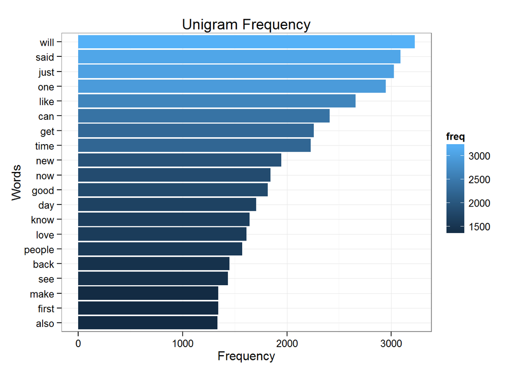

```r
## 1gram frequency
freq_1gram_top20 <- slice(freq_1gram, 1:20)
ggplot(freq_1gram_top20, aes(x=reorder(word,freq), y=freq, fill=freq)) +
        geom_bar(stat="identity") +
        theme_bw() +
        coord_flip() +
        labs(x="Words", y="Frequency", title="Unigram Frequency")
```

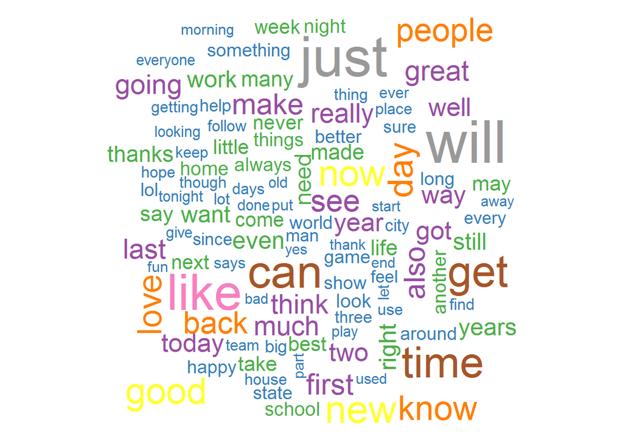

```r
## 1gram word cloud
wordcloud(freq_1gram$word, freq_1gram$freq, max.words=200, colors=brewer.pal(9,"Set1"))
```

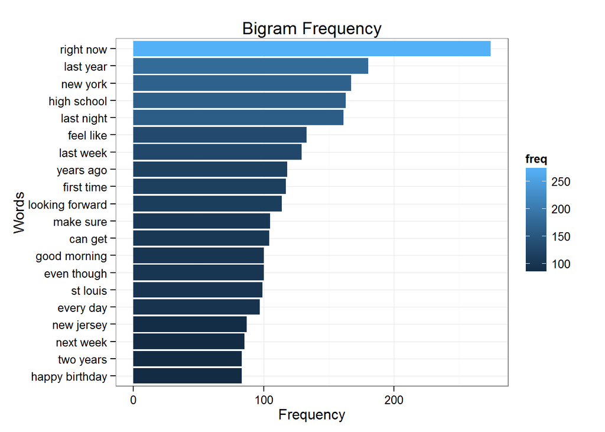

```r
## 2gram frequency
freq_2gram_top20 <- slice(freq_2gram, 1:20)
ggplot(freq_2gram_top20, aes(x=reorder(word,freq), y=freq, fill=freq)) +
        geom_bar(stat="identity") +
        theme_bw() +
        coord_flip() +
        labs(x="Words", y="Frequency", title="Bigram Frequency")
```

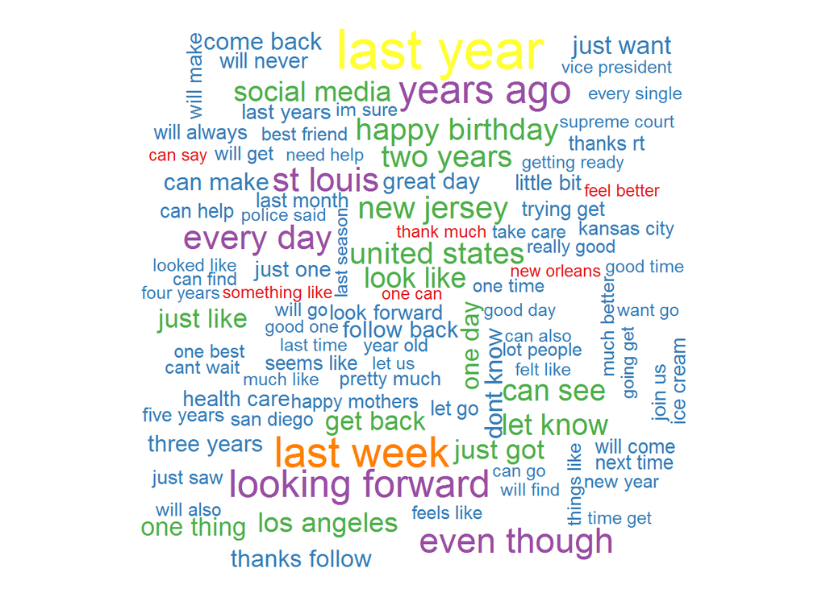

```r
## 2gram word cloud
wordcloud(freq_2gram$word, freq_2gram$freq, max.words=200, colors=brewer.pal(9,"Set1"))
```

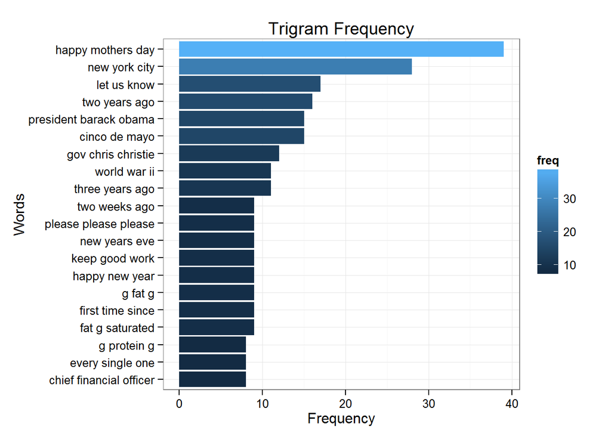

```r
## 3gram frequency
freq_3gram_top20 <- slice(freq_3gram, 1:20)
ggplot(freq_3gram_top20, aes(x=reorder(word,freq), y=freq, fill=freq)) +
        geom_bar(stat="identity") +
        theme_bw() +
        coord_flip() +
        labs(x="Words", y="Frequency", title="Trigram Frequency")
```

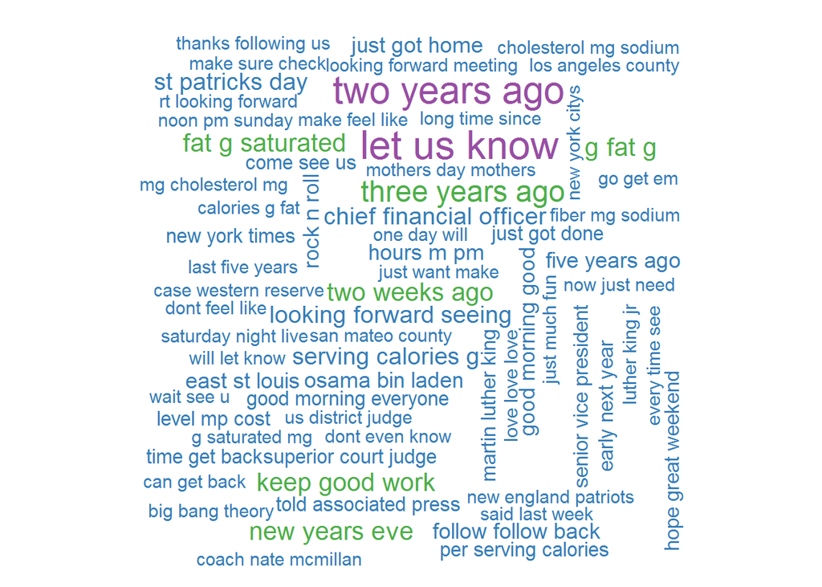

```r
## 3gram word cloud
wordcloud(freq_3gram$word, freq_3gram$freq, max.words=200, colors=brewer.pal(9,"Set1"))
```

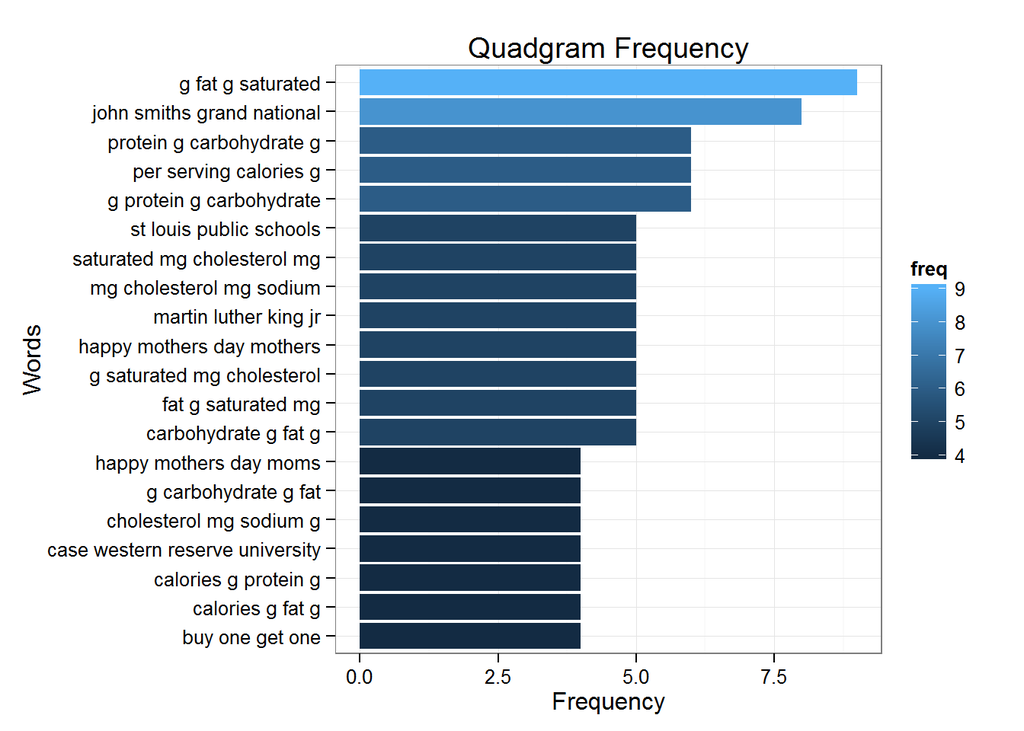

```r
## 4gram frequency
freq_4gram_top20 <- slice(freq_4gram, 1:20)
ggplot(freq_4gram_top20, aes(x=reorder(word,freq), y=freq, fill=freq)) +
        geom_bar(stat="identity") +
        theme_bw() +
        coord_flip() +
        labs(x="Words", y="Frequency", title="Quadgram Frequency")
```

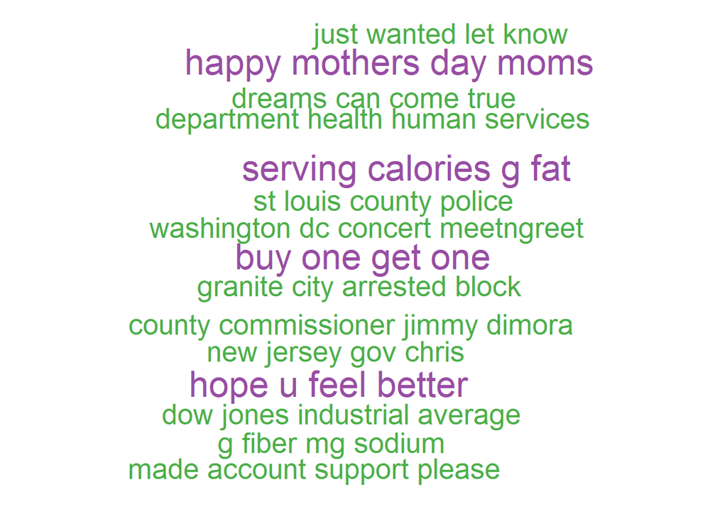

```r
## 4gram word cloud
wordcloud(freq_4gram$word, freq_4gram$freq, max.words=200, colors=brewer.pal(9,"Set1"))
```